# RBIF111 - Homework 8

Neshita Kipuw

2024-12-03

```r
# Load necessary packages
library(ggplot2)
library(tidyr)
library(dplyr)
library(stats)
library(DESeq2)
library(reshape2)
library(data.table)
library(survival)
```

# 1 Question 1

## 1.1 Logistic regression analysis on gene expression levels and the categorical variable.

#### 1.1.0.1 From normalized data set

The data set obtained from GEO is a study on gene expression profile characterization and gene-of-interest identification in normal, stenotic (AS), and regurgitant (AI) human aortic valves using RNA sequencing. The metadata contain several categorical variables such as gender, age, BMI, status of disease, and left-ventricle ejection fraction (to classify heart failure). The logistic regression perform analysis between gene expression and gender to identify which genes have the most significant effect on patient gender.

The code and results (hidden) below will download the normalized data set from GEO database. *May collapse the code and results*

```r
#GEO download
GEODataDownload <- function(DS, gpl, gsm, PlateAnnotInfo, GenerateMetaData, Technology){
  library(DESeq2); library(data.table)
  if(Technology == "Array"){
    gset <- getGEO(DS)
    if(length(gset) > 1) idx <- grep(gpl, attr(gset, "names")) else idx <- 1
    gset <- gset[[idx]]
    fvarLabels(gset) <- make.names(fvarLabels(gset))
    comp <- gsub(" ", "", gsm)
    comp <- gsub(",", "", comp)
    gsms <- paste0(comp)
    #### Set up raw names ####
    sml <- c()
    for(i in 1:nchar(gsms)){ sml[i] <- substr(gsms,i,i)}
    ex <- exprs(gset)
    qx <- as.numeric(quantile(ex, c(0., 0.25, 0.5, 0.75, 0.99, 1.0), na.rm=T))
    LogC <- (qx[5] > 100) ||
      (qx[6]-qx[1] > 50 && qx[2] > 0) ||
      (qx[2] > 0 && qx[2] < 1 && qx[4] < 2)
    if(LogC){ ex[which(ex <= 0)] <- NaN
    exprs(gset) <- log2(ex) }
    sml <- paste("G", sml, sep="")
    f1 <- as.factor(sml)
    gset$description2 <- f1
    design <- model.matrix(~description2 + 0, gset)
    colnames(design) <- levels(f1)
    fit <- lmFit(gset, design)
    cont.matrix <- makeContrasts(G1-G0, levels = design)
    fit2 <- contrasts.fit(fit, cont.matrix)
    fit2 <- eBayes(fit2, 0.01)
    tT <- topTable(fit2, adjust="fdr", sort.by = "B", number = 25000000000)
    #### subset ####
    ex2 <- data.table(subset(tT, select=c("ID", "logFC", "P.Value", "adj.P.Val")))
    ex2$ID <- as.character(ex2$ID)
    #### annotate with gene names ####
    plat <- PlateAnnotInfo[GPLID == gpl,][,!"GPLID", with = FALSE]
    if(nrow(plat) == 0){ print(paste("There is no annotation information available for", gpl)) }
    plat$ID <- as.character(plat$ID)
    plat <- plat[!duplicated(plat$ID),]
    ex2 <- merge(plat, ex2, by = "ID")
    ex2$ID <- as.character(ex2$ID)
    exraw <- data.table(ex)
    exraw$ID <- as.character(rownames(ex))
    #### annotate raw data with gene names ####
    ex2 <- merge(ex2, exraw, by = "ID")
    #### Generate Meta Data ####
    Pdat <- pData(gset)
    #### Add Meta data ####
    Pdat <- as.data.table(Pdat)
    return(list(Data = ex2, MetaData = Pdat))
  }

  if(Technology == "RNAseq"){
    ACC <- paste("acc=", DS, sep = "")
    file <- paste("file=", DS, "_raw_counts_GRCh38.p13_NCBI.tsv.gz", sep = "")
    comp <- gsub(" ", "", gsm)
    comp <- gsub(",", "", comp)
    gsms <- paste0(comp)
    #### Set up DEG names ####
    urld <- "https://www.ncbi.nlm.nih.gov/geo/download/?format=file&type=rnaseq_counts"
    path <- paste(urld, ACC, file, sep="&");
    tbl <- as.matrix(data.table::fread(path, header=T, colClasses="integer"), rownames="GeneID")
    exraw <- tbl
    apath <- paste(urld, "type=rnaseq_counts", "file=Human.GRCh38.p13.annot.tsv.gz", sep="&")
    annot <- data.table::fread(apath, header=T, quote="", stringsAsFactors=F, data.table=F)
    rownames(annot) <- annot$GeneID
    sml <- strsplit(gsms, split="")[[1]]
    sel <- which(sml != "X")
    sml <- sml[sel]
    tbl <- tbl[ ,sel]
    gs <- factor(sml)
    groups <- make.names(c("Ctrl", "Tx"))
    levels(gs) <- groups
    sample_info <- data.frame(Group = gs, row.names = colnames(tbl))
    keep <- rowSums( tbl >= 10 ) >= min(table(gs))
    tbl <- tbl[keep, ]
    ds <- DESeqDataSetFromMatrix(countData=tbl, colData=sample_info, design= ~Group)

    # Estimate size factors and get normalized counts
    ds <- estimateSizeFactors(ds)
    # Continue with DESeq analysis
    ds <- DESeq(ds, test="Wald", sfType="poscount")
    normalized_counts <- counts(ds, normalized=TRUE)

    r <- results(ds, contrast=c("Group", groups[2], groups[1]), alpha=0.05, pAdjustMethod ="fdr")
    tT <- r[order(r$padj)[1:length(r$padj)],]
    tT <- merge(as.data.frame(tT), annot, by.x="row.names", by.y="GeneID", sort=F)
    tT <- subset(tT, select=c("Row.names","padj","pvalue","lfcSE","stat","log2FoldChange","baseMean","Symbol","Description"))

    #### subset ####
    ex2 <- data.table(subset(tT, select=c("Row.names", "Symbol", "Description", "log2FoldChange", "pvalue", "padj")))
    setnames(ex2, c("Row.names", "Symbol", "Description"), c("ENTREZID", "SYMBOL", "GENENAME"))

    #### Get Raw data ####
    exraw <- as.data.table(exraw)
    exraw$ENTREZID <- rownames(exraw)

    #### merge FC and raw data together ####
    mer <- merge(ex2, exraw, by = "ENTREZID")

    # Add normalized counts to the merged data
    normalized_counts_dt <- as.data.table(normalized_counts, keep.rownames = "ENTREZID")
    final_table <- merge(mer, normalized_counts_dt, by = "ENTREZID")

    return(final_table)
  }
}

# Execute the GEODataDownload function and obtain the RNAseq data set
RNAseqData <- GEODataDownload(DS = "GSE153555",
                              gpl = "GPL16791",
                              gsm = "000000000111111111111111111",
                              PlateAnnotInfo = "Only needed if the data was generated using MicroArrays",
                              GenerateMetaData = "Only needed if the data was generated using MicroArrays",
                              Technology = "RNAseq")

# Save the RNAseq data set to the working directory
saveRDS(RNAseqData, file = "~/RNAseq_GSE153555_norm.rds")

# Reload the file into R environment
GSE153555 <- readRDS("~/RNAseq_GSE153555_norm.rds")

# Edit column names that end with ".y"
colnames(GSE153555) <- gsub(".y$", "", colnames(GSE153555))

# Clean up column names
remove_cols <- grepl(".x$", colnames(GSE153555))
GSE153555_2 <- subset(GSE153555, select = !remove_cols)
head(GSE153555_2)
```

The column below will add columns for the continuous variables associated with data set, obtained from the metadata.

```r
# Add in metadata from folder
metadata <- read.csv("./SRA_GSE153555.csv")
metadata <- metadata %>% mutate(degree_of_disease = as.factor(degree_of_disease),
                              Gender = as.factor(Gender))
head(metadata)
```

```
##   AGE  BMI degree_of_disease LV_ejection_fraction  Sample_ID Gender
## 1  56 22.0            Normal                 0.75 GSM4647026 female
## 2  56 22.0            Normal                 0.75 GSM4647027 female
## 3  17 21.6            Normal                 0.62 GSM4647028 female
## 4  17 21.6            Normal                 0.62 GSM4647029 female
## 5  31 36.0            Normal                 0.65 GSM4647030   male
## 6  31 36.0            Normal                 0.65 GSM4647031   male
```

```r
# Convert data set to long format to merge with sample annotation
GSE153555_3 <- reshape2::melt(GSE153555_2, id.vars = c("ENTREZID", "SYMBOL", "GENENAME", "log2FoldChange", "pvalue", "padj"), variable.name = "Sample_ID", value.name = "Expression")

# Merge the data frames by Sample_ID
GSE153555_4 <- merge(GSE153555_3, metadata, by = "Sample_ID", all.x = TRUE)

# Check the resulting converted data set
head(GSE153555_4)
```

```
##    Sample_ID ENTREZID SYMBOL                      GENENAME log2FoldChange
## 1 GSM4647026        1   A1BG        alpha-1-B glycoprotein     0.10262948
## 2 GSM4647026       10   NAT2         N-acetyltransferase 2    -0.23966882
## 3 GSM4647026      100    ADA           adenosine deaminase    -0.65125778
## 4 GSM4647026     1000   CDH2                    cadherin 2     0.55666589
## 5 GSM4647026    10000   AKT3 AKT serine/threonine kinase 3    -0.08120400
## 6 GSM4647026    10001   MED6    mediator complex subunit 6     0.01305281
##         pvalue         padj Expression AGE BMI degree_of_disease
## 1 6.431576e-01 0.7596378641   168.2974  56  22            Normal
## 2 5.474726e-01 0.6829035473    29.9587  56  22            Normal
## 3 9.339492e-05 0.0006326259   232.6205  56  22            Normal
## 4 1.660032e-04 0.0010393418  2938.5964  56  22            Normal
## 5 5.656949e-01 0.6972150530  4102.5802  56  22            Normal
## 6 8.801634e-01 0.9300382306   592.1250  56  22            Normal
##   LV_ejection_fraction Gender
## 1                 0.75 female
## 2                 0.75 female
## 3                 0.75 female
## 4                 0.75 female
## 5                 0.75 female
## 6                 0.75 female
```

The code below will perform the logistic regression analysis on gene expression and the effect on patient gender, and the results will be visualized.

```r
set.seed(123)
# Logistic Regression on gene expression and gender
log_reg <- GSE153555_4 %>%
  group_by(SYMBOL) %>%
  summarise(
    pvalue = {
        model <- glm(Gender ~ Expression,
                     family = binomial(link = "logit"),
                     data = pick(Expression, Gender))
        summary(model)$coefficients[2,4]
    }
  )

# Sort by p-value
top_genes <- log_reg %>% arrange(pvalue) %>% slice_head(n = 5)
print("Top 5 genes with the lowest p-values:")
```

```
## [1] "Top 5 genes with the lowest p-values:"
```

```r
print(top_genes)
```

```
## # A tibble: 5 × 2
##   SYMBOL  pvalue
##   <chr>    <dbl>
## 1 GDI2   0.00316
## 2 EIF1AX 0.00355
## 3 EIF1AY 0.00356
## 4 XIST   0.00413
## 5 GCNT2  0.00427
```

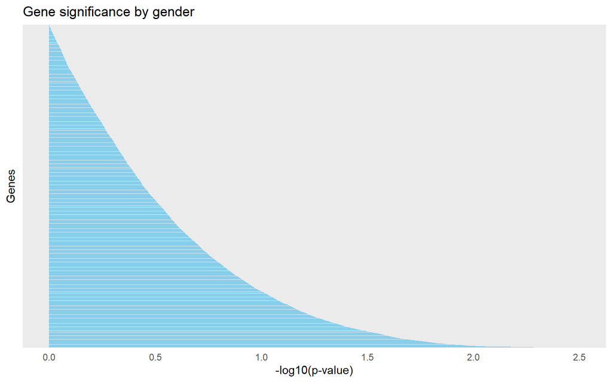

```r
# Plot p-values
ggplot(log_reg, aes(x = reorder(SYMBOL, pvalue), y = -log10(pvalue))) +
  geom_bar(stat = "identity", fill = "skyblue") +
  theme_minimal() +
  coord_flip() +
  labs(title = "Gene significance by gender", hjust = 0.5, face = "bold", size = 15,
       x = "Genes", size = 12, face = "bold",
       y = "-log10(p-value)", size = 12, face = "bold") +
  theme(axis.text.y = element_blank(), axis.ticks.y = element_blank())
```

### 1.1.1 Multiple hypothesis testing and leave-n-out resampling from normalized data set

The code below will perform multiple hypothesis testing by n = 100 resampling and leaving out n random samples each time. The top 5 most significant genes by p-value will be identified. The average p-value and variance from resampling will be calculated and reported. The gene with low average p-value and low variance across resampling is considered to be robustly associated with gender. Although not found in this top 5 list, genes with high variance may indicate unstable or sample-specific effects.

```r
set.seed(123)
n_resampling <- 100
n_leaveout <- 1

# Split data by gene
GSE153555_5 <- split(GSE153555_4, GSE153555_4$SYMBOL)

## Function for multiple hypothesis test & leave-n-out resampling
resample_pvalue <- function(GSE153555_4, n_resampling, n_leaveout) {
    replicate(n_resampling, {
        # leave out 5 random samples
        validation_sample <- sample(1:nrow(GSE153555_4), size = n_leaveout)
        training_data <- GSE153555_4[-validation_sample, ] # training set
        validation_data <- GSE153555_4[validation_sample, ] # validation set

        # fit logistic regression model
        model <- glm(Gender ~ Expression, family = binomial(link = "logit"), data = training_data)
        # get the p-value of the Expression coefficient
        summary(model)$coefficients[2,4]
    })
}

# Execute the function
my_resampling <- sapply(GSE153555_5, function(GSE153555_4) {
  p_values <- resample_pvalue(GSE153555_4, n_resampling, n_leaveout)
  c(avg_pvalue = mean(p_values, na.rm = TRUE), var_pvalue = var(p_values, na.rm = TRUE))
})

# Convert to data frame
my_summary <- as.data.frame(t(my_resampling))
colnames(my_summary) <- c("avg_pvalue", "var_pvalue")
my_summary$SYMBOL <- rownames(my_summary)
head(my_summary)
```

```
##       avg_pvalue   var_pvalue SYMBOL
## A1BG  0.70155815 1.580057e-02   A1BG
## A2M   0.08735235 6.862083e-04    A2M
## A2MP1 0.07076071 2.574407e-04  A2MP1
## AAAS  0.81339061 1.802663e-02   AAAS
## AADAC 0.58390686 1.881375e-02  AADAC
## AAK1  0.01501555 3.063380e-06   AAK1
```

```r
# Get top 5 results based on average p-values
top_resampling <- my_summary %>%
    arrange(avg_pvalue) %>%
    head(n = 5)

print("Top 5 genes from resampling with the lowest average p-values:")
```

```
## [1] "Top 5 genes from resampling with the lowest average p-values:"
```

```r
print(top_resampling)
```

```
##         avg_pvalue   var_pvalue SYMBOL
## GDI2   0.003937422 2.897323e-07   GDI2
## EIF1AX 0.004408892 5.104998e-07 EIF1AX
## EIF1AY 0.004523115 7.603968e-07 EIF1AY
## XIST   0.005008247 1.316686e-06   XIST
## GCNT2  0.005295393 9.766908e-07  GCNT2
```

**Discussion**  
The logistic regression show that the genes with the smallest p-values (< 0.05) indicate a significant effect on gender. The result of resampling help to validate these results by assessing consistency across multiple samples, which showed the same top 5 genes as the original logistic regression.

## 1.2 Repeat logistic regression analysis and multiple hypothesis testing on non-normalized data set

The (hidden) code below will download the data set as-is from GEO, i.e., not normalized.

```r
#GEO download
GEODataDownload <- function(DS, gpl, gsm, PlateAnnotInfo, GenerateMetaData, Technology){
  library(DESeq2); library(data.table)
  if(Technology == "Array"){
    gset <- getGEO(DS)
    if(length(gset) > 1) idx <- grep(gpl, attr(gset, "names")) else idx <- 1
    gset <- gset[[idx]]
    fvarLabels(gset) <- make.names(fvarLabels(gset))
    comp <- gsub(" ", "", gsm)
    comp <- gsub(",", "", comp)
    gsms <- paste0(comp)
    #### Set up raw names ####
    sml <- c()
    for(i in 1:nchar(gsms)){ sml[i] <- substr(gsms,i,i)}
    ex <- exprs(gset)
    qx <- as.numeric(quantile(ex, c(0., 0.25, 0.5, 0.75, 0.99, 1.0), na.rm=T))
    LogC <- (qx[5] > 100) ||
      (qx[6]-qx[1] > 50 && qx[2] > 0) ||
      (qx[2] > 0 && qx[2] < 1 && qx[4] < 2)
    if(LogC){ ex[which(ex <= 0)] <- NaN
    exprs(gset) <- log2(ex) }
    sml <- paste("G", sml, sep="")
    f1 <- as.factor(sml)
    gset$description2 <- f1
    design <- model.matrix(~description2 + 0, gset)
    colnames(design) <- levels(f1)
    fit <- lmFit(gset, design)
    cont.matrix <- makeContrasts(G1-G0, levels = design)
    fit2 <- contrasts.fit(fit, cont.matrix)
    fit2 <- eBayes(fit2, 0.01)
    tT <- topTable(fit2, adjust="fdr", sort.by = "B", number = 25000000000)
    #### subset ####
    ex2 <- data.table(subset(tT, select=c("ID", "logFC", "P.Value", "adj.P.Val")))
    ex2$ID <- as.character(ex2$ID)
    #### annotate with gene names ####
    plat <- PlateAnnotInfo[GPLID == gpl,][,!"GPLID", with = FALSE]
    if(nrow(plat) == 0){ print(paste("There is no annotation information available for", gpl)) }
    plat$ID <- as.character(plat$ID)
    plat <- plat[!duplicated(plat$ID),]
    ex2 <- merge(plat, ex2, by = "ID")
    ex2$ID <- as.character(ex2$ID)
    exraw <- data.table(ex)
    exraw$ID <- as.character(rownames(ex))
    #### annotate raw data with gene names ####
    ex2 <- merge(ex2, exraw, by = "ID")
    #### Generate Meta Data ####
    Pdat <- pData(gset)
    #### Add Meta data ####
    Pdat <- as.data.table(Pdat)
    return(list(Data = ex2, MetaData = Pdat))
  }

  if(Technology == "RNAseq"){
    ACC <- paste("acc=", DS, sep = "")
    file <- paste("file=", DS, "_raw_counts_GRCh38.p13_NCBI.tsv.gz", sep = "")
    comp <- gsub(" ", "", gsm)
    comp <- gsub(",", "", comp)
    gsms <- paste0(comp)
    #### Set up DEG names ####
    urld <- "https://www.ncbi.nlm.nih.gov/geo/download/?format=file&type=rnaseq_counts"
    path <- paste(urld, ACC, file, sep="&");
    tbl <- as.matrix(data.table::fread(path, header=T, colClasses="integer"), rownames="GeneID")
    exraw <- tbl
    apath <- paste(urld, "type=rnaseq_counts", "file=Human.GRCh38.p13.annot.tsv.gz", sep="&")
    annot <- data.table::fread(apath, header=T, quote="", stringsAsFactors=F, data.table=F)
    rownames(annot) <- annot$GeneID
    sml <- strsplit(gsms, split="")[[1]]
    sel <- which(sml != "X")
    sml <- sml[sel]
    tbl <- tbl[ ,sel]
    gs <- factor(sml)
    groups <- make.names(c("Ctrl", "Tx"))
    levels(gs) <- groups
    sample_info <- data.frame(Group = gs, row.names = colnames(tbl))
    keep <- rowSums( tbl >= 10 ) >= min(table(gs))
    tbl <- tbl[keep, ]
    ds <- DESeqDataSetFromMatrix(countData=tbl, colData=sample_info, design= ~Group)
    ds <- DESeq(ds, test="Wald", sfType="poscount")
    r <- results(ds, contrast=c("Group", groups[2], groups[1]), alpha=0.05, pAdjustMethod ="fdr")
    tT <- r[order(r$padj)[1:length(r$padj)],]
    tT <- merge(as.data.frame(tT), annot, by=0, sort=F)
    tT <- subset(tT, select=c("GeneID","padj","pvalue","lfcSE","stat","log2FoldChange","baseMean","Symbol","Description"))
    #### subset ####
    ex2 <- data.table(subset(tT, select=c("GeneID", "Symbol", "Description", "log2FoldChange", "pvalue", "padj")))
    #### Adjust column names ####
    setnames(ex2, c("GeneID", "Symbol", "Description"), c("ENTREZID", "SYMBOL", "GENENAME"))
    #### Get Raw data ####
    GeneID <- as.integer(rownames(exraw))
    exraw <- as.data.table(exraw)
    #### Update column names ####
    exraw$ENTREZID <- GeneID
    #### merge FC and raw data together ####
    mer <- merge(ex2, exraw, by = "ENTREZID")
    return(mer)  }
}

# Execute the GEODataDownload function and obtain the RNAseq data set
RNAseqData2 <- GEODataDownload(DS = "GSE153555",
                              gpl = "GPL16791",
                              gsm = "000000000111111111111111111",
                              PlateAnnotInfo = "Only needed if the data was generated using MicroArrays",
                              GenerateMetaData = "Only needed if the data was generated using MicroArrays",
                              Technology = "RNAseq")

# Save the RNAseq data set to the working directory
saveRDS(RNAseqData2, file = "~/RNAseq_GSE153555.rds")

# Reload the file into R environment
GSE153555v2 <- readRDS("~/RNAseq_GSE153555.rds")

# Edit column names that end with ".y"
#colnames(GSE153555v2) <- gsub(".y$", "", colnames(GSE153555v2))

# Clean up column names
#remove_cols <- grepl(".x$", colnames(GSE153555v2))
#GSE153555v2_2 <- subset(GSE153555v2, select = !remove_cols)
head(GSE153555v2)
```

The column below will add columns for the continuous variables associated with data set, obtained from the metadata.

```r
# Grab previously downloaded metadata
head(metadata)
```

```
##   AGE  BMI degree_of_disease LV_ejection_fraction  Sample_ID Gender
## 1  56 22.0            Normal                 0.75 GSM4647026 female
## 2  56 22.0            Normal                 0.75 GSM4647027 female
## 3  17 21.6            Normal                 0.62 GSM4647028 female
## 4  17 21.6            Normal                 0.62 GSM4647029 female
## 5  31 36.0            Normal                 0.65 GSM4647030   male
## 6  31 36.0            Normal                 0.65 GSM4647031   male
```

```r
# Convert data set to long format to merge with sample annotation
GSE153555v2_2 <- reshape2::melt(GSE153555v2, id.vars = c("ENTREZID", "SYMBOL", "GENENAME", "log2FoldChange", "pvalue", "padj"), variable.name = "Sample_ID", value.name = "Expression")

# Merge the data frames by Sample_ID
GSE153555v2_3 <- merge(GSE153555v2_2, metadata, by = "Sample_ID", all.x = TRUE)

# Check the resulting converted data set
head(GSE153555v2_3)
```

```
##    Sample_ID ENTREZID   SYMBOL                           GENENAME
## 1 GSM4647026        1     A1BG             alpha-1-B glycoprotein
## 2 GSM4647026        2      A2M              alpha-2-macroglobulin
## 3 GSM4647026        3    A2MP1 alpha-2-macroglobulin pseudogene 1
## 4 GSM4647026        9     NAT1              N-acetyltransferase 1
## 5 GSM4647026       10     NAT2              N-acetyltransferase 2
## 6 GSM4647026       12 SERPINA3           serpin family A member 3
##   log2FoldChange       pvalue         padj Expression AGE BMI degree_of_disease
## 1      0.1080052 6.231660e-01 7.432849e-01        191  56  22            Normal
## 2      0.1382749 5.151538e-01 6.560771e-01      51047  56  22            Normal
## 3     -0.4968724 5.441988e-01 6.802073e-01         19  56  22            Normal
## 4      0.3396938 9.373006e-03 3.170845e-02        337  56  22            Normal
## 5     -0.2311183 5.612775e-01 6.949598e-01         34  56  22            Normal
## 6     -1.8628518 1.321601e-41 1.607689e-38      47347  56  22            Normal
##   LV_ejection_fraction Gender
## 1                 0.75 female
## 2                 0.75 female
## 3                 0.75 female
## 4                 0.75 female
## 5                 0.75 female
## 6                 0.75 female
```

The code below will perform the logistic regression analysis on gene expression and the effect on patient gender, and the results will be visualized.

```r
set.seed(123)
# Logistic Regression on gene expression and gender
log_reg2 <- GSE153555v2_3 %>%
  group_by(SYMBOL) %>%
  summarise(
    pvalue = {
        model <- glm(Gender ~ Expression,
                     family = binomial(link = "logit"),
                     data = pick(Expression, Gender))
        summary(model)$coefficients[2,4]
    }
  )

# Sort by p-value
top_genes2 <- log_reg2 %>% arrange(pvalue) %>% slice_head(n = 5)
print("Top 5 genes with the lowest p-values:")
```

```
## [1] "Top 5 genes with the lowest p-values:"
```

```r
print(top_genes2)
```

```
## # A tibble: 5 × 2
##   SYMBOL        pvalue
##   <chr>          <dbl>
## 1 EIF1AY       0.00423
## 2 XIST         0.00496
## 3 LOC112268311 0.00509
## 4 HORMAD1      0.00522
## 5 RPS4Y1       0.00535
```

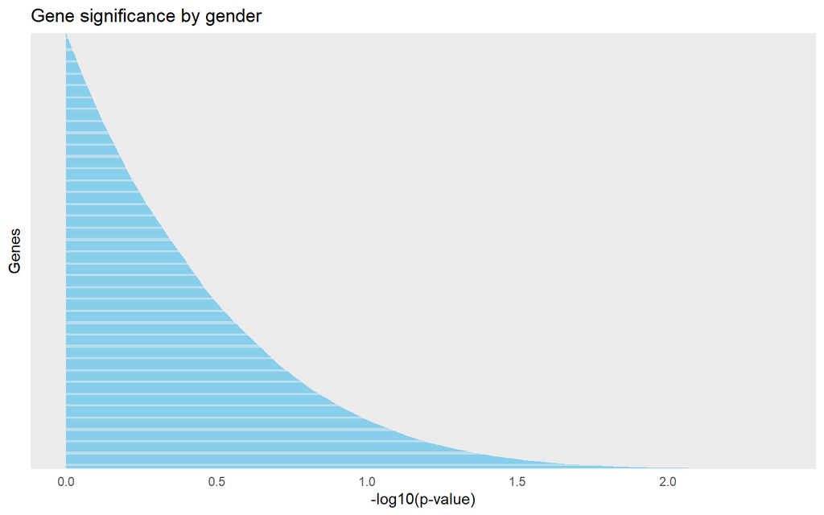

```r
# Plot p-values
ggplot(log_reg2, aes(x = reorder(SYMBOL, pvalue), y = -log10(pvalue))) +
  geom_bar(stat = "identity", fill = "skyblue") +
  theme_minimal() +
  coord_flip() +
  labs(title = "Gene significance by gender", hjust = 0.5, face = "bold", size = 15,
       x = "Genes", size = 12, face = "bold",
       y = "-log10(p-value)", size = 12, face = "bold") +
  theme(axis.text.y = element_blank(), axis.ticks.y = element_blank())
```

### 1.2.1 Multiple hypothesis testing and leave-one-out resampling from non-normalized data set

The code below will perform multiple hypothesis testing by n = 100 resampling and leaving out n random sample each time. The top 5 most significant genes by p-value will be identified. The average p-value and variance from resampling will be calculated and reported.

```r
set.seed(123)
## Recall the previous variables
# n_resampling <- 100
# n_leaveout <- 1

# Split data by gene
GSE153555v2_4 <- split(GSE153555v2_3, GSE153555v2_3$SYMBOL)

## Function for multiple hypothesis test & leave-n-out resampling
resample_pvalue2 <- function(GSE153555v2_3, n_resampling, n_leaveout) {
    replicate(n_resampling, {
        # leave out 5 random samples
        validation_sample2 <- sample(1:nrow(GSE153555v2_3), size = n_leaveout)
        training_data2 <- GSE153555v2_3[-validation_sample2, ] # training set
        validation_data2 <- GSE153555v2_3[validation_sample2, ] # validation set

        # fit logistic regression model
        model2 <- glm(Gender ~ Expression, family = binomial(link = "logit"), data = training_data2)
        # get the p-value of the Expression coefficient
        summary(model2)$coefficients[2,4]
    })
}

# Execute the function
my_resampling2 <- sapply(GSE153555v2_4, function(GSE153555v2_3) {
  p_values2 <- resample_pvalue2(GSE153555v2_3, n_resampling, n_leaveout)
  c(avg_pvalue = mean(p_values2, na.rm = TRUE), var_pvalue = var(p_values2, na.rm = TRUE))
})

# Convert to data frame
my_summary2 <- as.data.frame(t(my_resampling2))
colnames(my_summary2) <- c("avg_pvalue", "var_pvalue")
my_summary2$SYMBOL <- rownames(my_summary2)
head(my_summary2)
```

```
##          avg_pvalue   var_pvalue   SYMBOL
## A1BG     0.85898245 0.0224213782     A1BG
## A1BG-AS1 0.09212002 0.0007290261 A1BG-AS1
## A2M      0.10399686 0.0008068959      A2M
## A2M-AS1  0.43806185 0.0087310220  A2M-AS1
## A2ML1    0.83351559 0.0162467488    A2ML1
## A2MP1    0.08242933 0.0005730878    A2MP1
```

```r
# Get top 5 results based on average p-values
top_resampling2 <- my_summary2 %>%
    arrange(avg_pvalue) %>%
    head(n = 5)

print("Top 5 genes from resampling with the lowest average p-values:")
```

```
## [1] "Top 5 genes from resampling with the lowest average p-values:"
```

```r
print(top_resampling2)
```

```
##               avg_pvalue   var_pvalue       SYMBOL
## EIF1AY       0.005151713 1.306658e-06       EIF1AY
## LOC112268311 0.006131693 6.561055e-07 LOC112268311
## XIST         0.006246087 1.559005e-06         XIST
## HORMAD1      0.006276823 1.316481e-06      HORMAD1
## LOC107984270 0.006660693 2.211839e-06 LOC107984270
```

**Discussion**  
The logistic regression for non-normalized data set also show small p-values < 0.05, indicating significant effect on gender. The resampling helps to validate the top 5 genes results from logistic regression, showing a similar list. Despite the low average p-values and small variance of p-values from resampling, only 2 genes (EIF1AY and XIST) out of the top 5 most significant genes were identified in both non- and normalized data sets. Therefore, careful examination of the original data should be considered to determine whether normalization would be required, as there is quite a notable difference between non- and normalized data, which impact the results greatly. Non-normalized data will have large differences in scale, leading to certain genes dominating the model due to extreme values, even if these differences are potentially not meaningful. Normalization then reduces this effect, allowing for more reliable comparisons and reducing the variability. Additionally, non-normalized data may display skewness or non-uniform distribution across samples, while normalized data is closer to a Gaussian distribution thereby the significant genes are more likely to reflect genuine biological results.

# 2 Question 2

## 2.1 Time-to-event survival analysis

The data was downloaded from the SurvSet Library, and contains information on the survival of subjects who are habitual smokers for a time period measured in years. The data contains information such as age, gender, the number of years the subject has been smoking, etc. The code below will load the data set into the R environment to perform the survival analysis. THen the data will be further analyzed to take into account the gender of the subjects.

```r
# Load the data set
mydata <- read.csv("./pharmacoSmoking.csv")
head(mydata)
```

```
##   pid event time num_age num_yearsSmoking num_priorAttempts num_longestNoSmoke
## 1  21     0  182      36               26                 0                  0
## 2 113     1   14      41               27                 3                 90
## 3  39     1    5      25               12                 3                 21
## 4  80     1   16      54               39                 0                  0
## 5  87     1    0      45               30                 0                  0
## 6  29     0  182      43               30                 2               1825
##       fac_grp fac_gender fac_race fac_employment fac_levelSmoking fac_ageGroup2
## 1   patchOnly       Male    white             ft            heavy         21-49
## 2   patchOnly       Male    white          other            heavy         21-49
## 3 combination     Female    white          other            heavy         21-49
## 4 combination       Male    white             ft            heavy           50+
## 5 combination       Male    white          other            heavy         21-49
## 6 combination       Male hispanic             ft            heavy         21-49
##   fac_ageGroup4
## 1         35-49
## 2         35-49
## 3         21-34
## 4         50-64
## 5         35-49
## 6         35-49
```

```r
summary(mydata)
```

```
##       pid             event            time           num_age
##  Min.   :  1.00   Min.   :0.000   Min.   :  0.00   Min.   :22.00
##  1st Qu.: 33.00   1st Qu.:0.000   1st Qu.:  8.00   1st Qu.:41.00
##  Median : 67.00   Median :1.000   Median : 49.00   Median :49.00
##  Mean   : 66.15   Mean   :0.712   Mean   : 77.44   Mean   :48.84
##  3rd Qu.: 99.00   3rd Qu.:1.000   3rd Qu.:182.00   3rd Qu.:56.00
##  Max.   :130.00   Max.   :1.000   Max.   :182.00   Max.   :86.00
##  num_yearsSmoking num_priorAttempts num_longestNoSmoke   fac_grp
##  Min.   : 9.00    Min.   :   0.00   Min.   :   0.0     Length:125
##  1st Qu.:22.00    1st Qu.:   1.00   1st Qu.:   7.0     Class :character
##  Median :30.00    Median :   2.00   Median :  90.0     Mode  :character
##  Mean   :30.88    Mean   :  12.68   Mean   : 539.7
##  3rd Qu.:39.00    3rd Qu.:   5.00   3rd Qu.: 365.0
##  Max.   :56.00    Max.   :1000.00   Max.   :6205.0
##   fac_gender          fac_race         fac_employment     fac_levelSmoking
##  Length:125         Length:125         Length:125         Length:125
##  Class :character   Class :character   Class :character   Class :character
##  Mode  :character   Mode  :character   Mode  :character   Mode  :character
##
##
##
##  fac_ageGroup2      fac_ageGroup4
##  Length:125         Length:125
##  Class :character   Class :character
##  Mode  :character   Mode  :character
##
##
##
```

```r
# Analyse the data
survival_data <- Surv(time = mydata$num_yearsSmoking, event = mydata$event)
head(survival_data)
```

```
## [1] 26+ 27  12  39  30  30+
```

```r
# Fit Kaplan-Meier survival curves
km_fit <- survfit(survival_data ~ mydata$fac_gender)
summary(km_fit)
```

```
## Call: survfit(formula = survival_data ~ mydata$fac_gender)
##
##                 mydata$fac_gender=Female
##  time n.risk n.event survival std.err lower 95% CI upper 95% CI
##     9     81       1   0.9877  0.0123      0.96390        1.000
##    10     80       3   0.9506  0.0241      0.90459        0.999
##    11     76       1   0.9381  0.0268      0.88701        0.992
##    12     75       2   0.9131  0.0314      0.85359        0.977
##    13     73       1   0.9006  0.0334      0.83751        0.968
##    15     72       2   0.8756  0.0368      0.80628        0.951
##    18     70       4   0.8255  0.0424      0.74652        0.913
##    20     65       3   0.7874  0.0458      0.70264        0.882
##    22     59       1   0.7741  0.0469      0.68741        0.872
##    23     58       3   0.7340  0.0499      0.64257        0.839
##    24     55       1   0.7207  0.0507      0.62788        0.827
```

[output cut: 44 more lines]

The (hidden) code below will plot the survival curves for the survival probability vs. years of smoking, classified by gender.

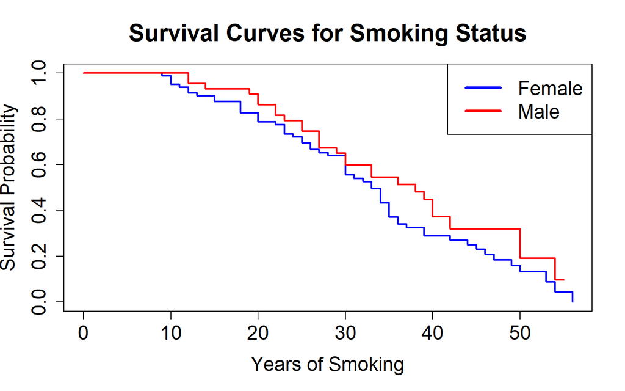

```r
# Plot survival curves
plot(km_fit, col = c("blue", "red"),
     xlab = "Years of Smoking",
     ylab = "Survival Probability",
     main = "Survival Curves for Smoking Status",
     cex.lab = 1.5,
     cex.axis = 1.5,
     cex.main = 1.8,
     lwd = 2)
legend("topright",
       legend = levels(as.factor(mydata$fac_gender)),
       col = c("blue", "red"),
       cex = 1.5,
       lwd = 3)
```